# Estudio sobre la Gamificación en UTEC como alternativa a la educación tradicional

En este estudio intentamos encontrar si existe una mejora de la calidad educativa utilizando la *Gamificación* para los estudiantes en UTEC. Para esto, diseñamos un experimento en el que dos grupos (seleccionados por los entrevistadores), uno que utiliza la experiencia tradicional de educación y el otro el cual recibe una educación con un videojuego llamado “Pc building simulator”. Ambos experimentos se diseñaron para durar aproximadamente 15 minutos y se diseñaron para cubrir el mismo material.

Primero la carga de data y la instalación de los paquetes.

```r
library(readr)
library(dplyr)
```

```r
library(ggplot2)
library(lubridate)
library(stringr)

DF <- read_csv("data.csv")
```

LIMPIEZA DE TIEMPO!!!

```r
DF$`Duración de la experiencia` <- gsub("\\.", ":", DF$`Duración de la experiencia`)
DF$`Duración de la experiencia` <- gsub(" ", "", DF$`Duración de la experiencia`)
DF$`Duración de la experiencia` <- gsub("minutos", "", DF$`Duración de la experiencia`)
DF$`Duración de la experiencia` <- gsub("min", "", DF$`Duración de la experiencia`)
DF$`Duración de la experiencia` <- gsub("pm", "", DF$`Duración de la experiencia`)
```

```r
iterator = 1
for (palabras in DF$`Duración de la experiencia`){
  if(!is.na(palabras)){
    if(nchar(palabras)<3){
            DF$`Duración de la experiencia`[iterator] <- paste0(DF$`Duración de la experiencia`[iterator],":00")
            #print(iterator)
      }
    }

    iterator = iterator + 1
}

DF$`Duración de la experiencia`
```

```
##  [1] "15:35" "28:25" "16:25" "17:15" "20:00" "16:36" "23:21" "17:20" "16:40"
## [10] "6:40"  "19:25" "15:25" "17:30" "8:00"  "29:49" "15:50" "15:35" "17:35"
## [19] "13:20" "18:30" "15:10" "16:08" "16:20" "18:35" "17:15" "14:42" "25:40"
## [28] "18:10" "24:00" "18:30" "13:47" "18:15" "18:35" "15:08" "16:58" "7:33"
## [37] "14:25" "17:38" "14:50" "12:05" "15:38" "18:52" "18:52" "25:32" "18:54"
## [46] "20:10" "17:00" "16:00" "20:10" "15:10" "17:00" "15:13" "20:00" "16:41"
## [55] "24:40" "11:10" "14:50" "15:00" "15:00" "17:00" "13:20" "17:20" "19:20"
## [64] "18:15" "17:30" "12:10" "9:30"  "18:30" "27:05" "12:30" "14:33" NA
## [73] "17:20" "16:00" "15:20" "17:32" "26:20" "16:05" "21:25" "2:00"  NA
## [82] NA      NA      NA      NA
```

```r
DF <- DF[complete.cases(DF$`Duración de la experiencia`),]
Duracion <- c()

for (duracion in DF$`Duración de la experiencia`)
{
    minuto <- str_extract(duracion, "[0-9]*")
    Duracion <- append(Duracion, strtoi(minuto))
}

Duracion
```

```
##  [1] 15 28 16 17 20 16 23 17 16  6 19 15 17  8 29 15 15 17 13 18 15 16 16 18 17
## [26] 14 25 18 24 18 13 18 18 15 16  7 14 17 14 12 15 18 18 25 18 20 17 16 20 15
## [51] 17 15 20 16 24 11 14 15 15 17 13 17 19 18 17 12  9 18 27 12 14 17 16 15 17
## [76] 26 16 21  2
```

ESTE CODIGO ARREGLA EL PROBLEMA DE “LEER DOCUMENTO” Y “LEER DOCUMENTO PDF”

```r
iterator = 1
for (palabras in DF$`Qué experiencia realizaste:`){
  if(!is.na(palabras)){
    if(palabras=="Leer Documento"){
            DF$`Qué experiencia realizaste:`[iterator] <- paste0(DF$`Qué experiencia realizaste:`[iterator]," PDF")
            #print(iterator)
      }
    }

    iterator = iterator + 1
}
DF$`Qué experiencia realizaste:`
```

```
##  [1] "Leer Documento PDF" "Leer Documento PDF" "Leer Documento PDF"
##  [4] "Leer Documento PDF" "Leer Documento PDF" "Leer Documento PDF"
##  [7] "Jugar PC Simulator" "Jugar PC Simulator" "Jugar PC Simulator"
## [10] "Jugar PC Simulator" "Leer Documento PDF" "Leer Documento PDF"
## [13] "Jugar PC Simulator" "Jugar PC Simulator" "Jugar PC Simulator"
## [16] "Leer Documento PDF" "Jugar PC Simulator" "Jugar PC Simulator"
## [19] "Jugar PC Simulator" "Jugar PC Simulator" "Jugar PC Simulator"
## [22] "Leer Documento PDF" "Jugar PC Simulator" "Leer Documento PDF"
## [25] "Jugar PC Simulator" "Jugar PC Simulator" "Jugar PC Simulator"
## [28] "Jugar PC Simulator" "Jugar PC Simulator" "Jugar PC Simulator"
## [31] "Jugar PC Simulator" "Jugar PC Simulator" "Leer Documento PDF"
## [34] "Jugar PC Simulator" "Jugar PC Simulator" "Jugar PC Simulator"
## [37] "Leer Documento PDF" "Jugar PC Simulator" "Jugar PC Simulator"
## [40] "Leer Documento PDF" "Jugar PC Simulator" "Jugar PC Simulator"
## [43] "Leer Documento PDF" "Jugar PC Simulator" "Jugar PC Simulator"
## [46] "Jugar PC Simulator" "Leer Documento PDF" "Leer Documento PDF"
## [49] "Leer Documento PDF" "Jugar PC Simulator" "Jugar PC Simulator"
## [52] "Jugar PC Simulator" "Leer Documento PDF" "Jugar PC Simulator"
## [55] "Jugar PC Simulator" "Leer Documento PDF" "Leer Documento PDF"
## [58] "Leer Documento PDF" "Leer Documento PDF" "Leer Documento PDF"
## [61] "Jugar PC Simulator" "Jugar PC Simulator" "Leer Documento PDF"
## [64] "Leer Documento PDF" "Leer Documento PDF" "Leer Documento PDF"
## [67] "Leer Documento PDF" "Leer Documento PDF" "Jugar PC Simulator"
## [70] "Leer Documento PDF" "Leer Documento PDF" "Leer Documento PDF"
## [73] "Leer Documento PDF" "Leer Documento PDF" "Jugar PC Simulator"
## [76] "Jugar PC Simulator" "Jugar PC Simulator" "Jugar PC Simulator"
## [79] "Leer Documento PDF"
```

Luego hemos calculado las respuestas correctas “a mano”, hemos considerado que los NA como respuestas validas pero con valor de 0.

```r
score_vector = c()

for (ans in DF$`Regula y proporciona la potencia para que se activen todos los componentes de la PC:`)
{
  if (!is.na(ans))
  {
    if (ans == "Fuente de alimentación (PSU) o sistema de alimentación")
    {
      score_vector <- append(score_vector, 1)
    }
    else
    {
      score_vector <- append(score_vector, 0)
    }
  }
  else
  {
    score_vector <- append(score_vector, 0)
  }

}

iterator = 1
for (ans in DF$`Cuenta con sus propios procesadores y memoria interna que procesa los datos de la PC y los representa en forma de texto o gráficas complejas como la de los videojuegos. Nos referimos a:`)
{
  if (!is.na(ans))
  {
    if (ans == "Tarjeta gráfica (GPU)")
    {
      score_vector[iterator] = score_vector[iterator] + 1
    }
  }

  iterator = iterator + 1
}


iterator = 1
for (ans in DF$`Responsable realiza cálculos basados en la interpretación de la información de ciertos componentes y les pasa el resultado a otros. Nos referimos a:`)
{
  if (!is.na(ans))
  {
    if (ans == "Unidad central de procesamiento o Procesador (CPU)")
    {
      score_vector[iterator] <- score_vector[iterator] + 1
    }
  }

  iterator = iterator + 1
}


iterator = 1
for (ans in DF$`Almacena todos los datos del sistema operativo, los programas y las fotos, la música y los vídeos del usuario. Es decir, es el dispositivo de almacenamiento del ordenador.`)
{
  if (!is.na(ans))
  {
    if (ans == "Disco Duro")
    {
      score_vector[iterator] <- score_vector[iterator] + 1
    }
  }

  iterator = iterator + 1
}

iterator = 1
for (ans in DF$`¿Dónde se conecta o instala la memoria (RAM)?`)
{
  if (!is.na(ans))
  {
    if (ans == "Placa base (Motherboard)")
    {
      score_vector[iterator] <- score_vector[iterator] + 1
    }
  }

  iterator = iterator + 1
}

iterator = 1
for (ans in DF$`¿Dónde se coloca la pasta térmica?`)
{
  if (!is.na(ans))
  {
    if (ans == "Unidad central de procesamiento o Procesador (CPU)")
    {
      score_vector[iterator] <- score_vector[iterator] + 1
    }
  }

  iterator = iterator + 1
}

iterator = 1
for (ans in DF$`¿A que parte se conecta el panel frontal de la caja (botón de encendido/apagado, USB, conector de audio, etc)?`)
{
  if (!is.na(ans))
  {
    if (ans == "Placa base (Motherboard)")
    {
      score_vector[iterator] <- score_vector[iterator] + 1
    }
  }

  iterator = iterator + 1
}



DF_scored <- cbind(DF, score_vector)
```

Luego de medir el puntaje hemos dividido las respuestas en los dos grupos correspondientes. Por ultimo hemos hecho una resta de filas debido a que hubo un imbalance de experimentos. Notar que aunque se quitaron filas y se puede considerar *MANIPULACIÓN DE DATOS* dichas columnas fueron removidas sin ningún tipo de “filtro” en particular mas que el orden en el que llegaron. Por lo que, se puede considerar “Aleatorio” las filas que se quitaron.

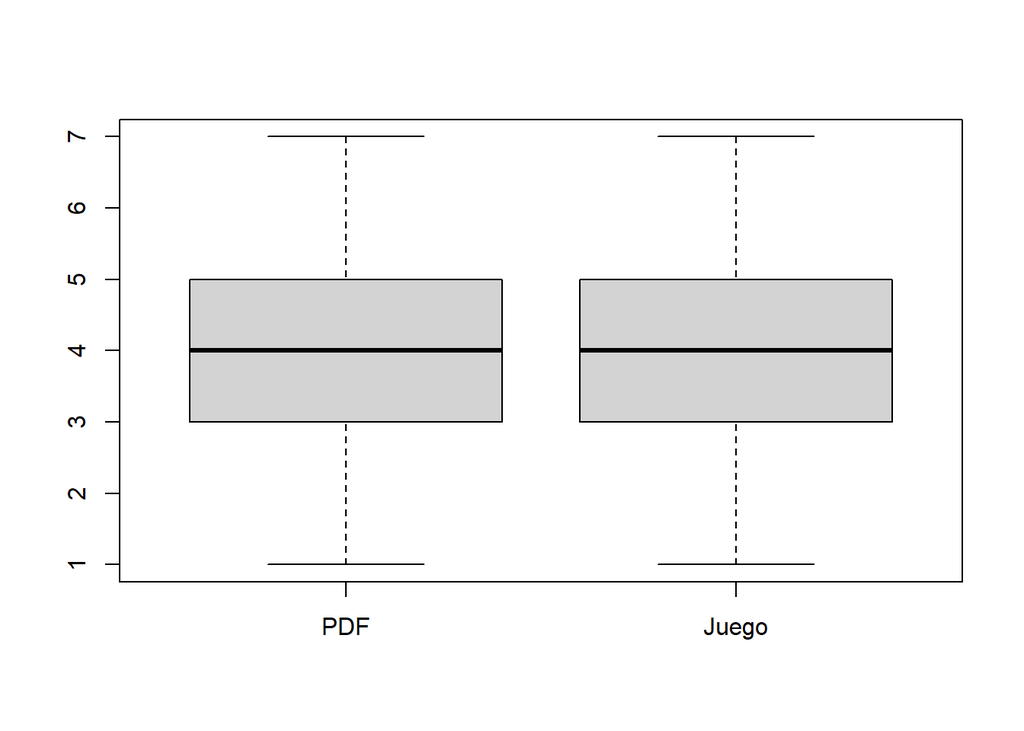

```r
class_learning <- DF_scored[DF_scored$`Qué experiencia realizaste:` == 'Leer Documento PDF',]



game_learning <- DF_scored[DF_scored$`Qué experiencia realizaste:` == 'Jugar PC Simulator',]

game_learning_cortado <- head(game_learning, nrow(class_learning) - nrow(game_learning))


data <- data.frame(class_learning$score_vector, game_learning_cortado$score_vector)
boxplot(data,names = c("PDF", "Juego"))
```

Tambien podemos medir la nota contra la experiencia de cada alumno

Grafica para los que hirieron clase de su nivel de experiencia armando pc contra su puntaje

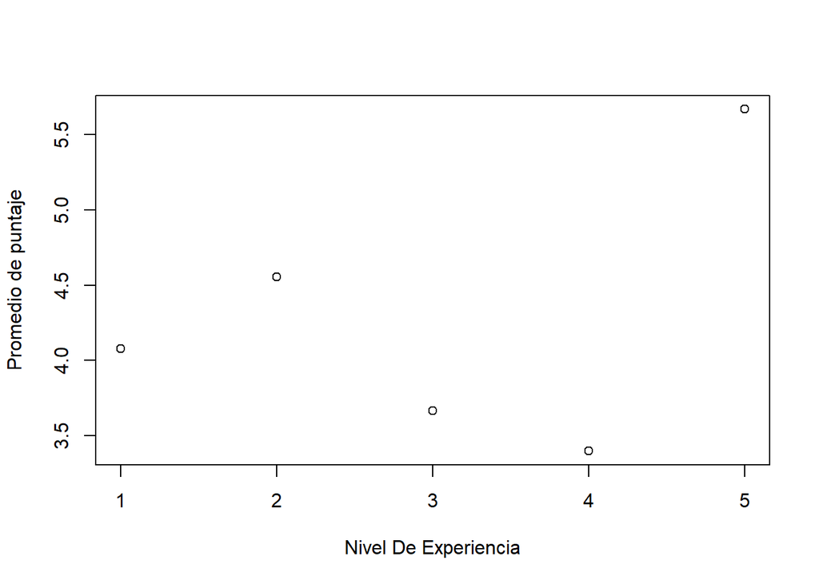

```r
score_mean <- c(0,0,0,0,0)
number_to_divide <- c(0,0,0,0,0)

for (row in 1:nrow(class_learning))
{
  score_mean[class_learning[row, "¿Cuál es tu nivel de experiencia armando computadoras?"]] <- score_mean[class_learning[row, "¿Cuál es tu nivel de experiencia armando computadoras?"]] + class_learning[row, "score_vector"]
  number_to_divide[class_learning[row, "¿Cuál es tu nivel de experiencia armando computadoras?"]] <- number_to_divide[class_learning[row, "¿Cuál es tu nivel de experiencia armando computadoras?"]] + 1
}

for (iterator in 1:5)
{
  score_mean[iterator] = score_mean[iterator]/number_to_divide[iterator]
}


possible <- c(1,2,3,4,5)

plot(possible, score_mean, xlab = "Nivel De Experiencia", ylab = "Promedio de puntaje")
```

Grafica para los que hirieron videojuego de su nivel de experiencia armando pc contra su puntaje

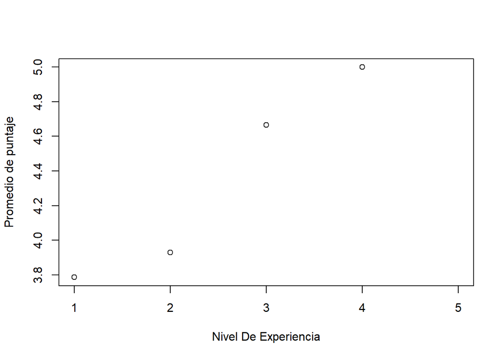

```r
score_mean <- score_mean[complete.cases(score_mean)]
score_mean <- c(0,0,0,0,0)
number_to_divide <- c(0,0,0,0,0)

for (row in 1:nrow(game_learning_cortado))
{
  score_mean[game_learning_cortado[row, "¿Cuál es tu nivel de experiencia armando computadoras?"]] <- score_mean[game_learning_cortado[row, "¿Cuál es tu nivel de experiencia armando computadoras?"]] + game_learning_cortado[row, "score_vector"]
  number_to_divide[game_learning_cortado[row, "¿Cuál es tu nivel de experiencia armando computadoras?"]] <- number_to_divide[game_learning_cortado[row, "¿Cuál es tu nivel de experiencia armando computadoras?"]] + 1
}

for (iterator in 1:5)
{
  score_mean[iterator] = score_mean[iterator]/number_to_divide[iterator]
}

possible <- c(1,2,3,4,5)

plot(possible, score_mean, xlab = "Nivel De Experiencia", ylab = "Promedio de puntaje")
```

Grafica de los que jugaron clase de su nivel de experiencia con los componentes de una computadora vs su puntaje

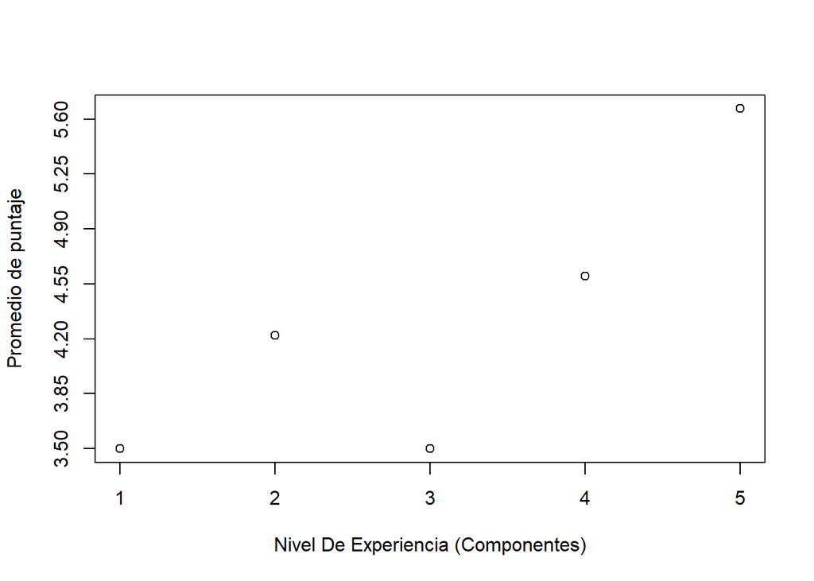

```r
score_mean <- score_mean[complete.cases(score_mean)]
score_mean <- c(0,0,0,0,0)
number_to_divide <- c(0,0,0,0,0)

for (row in 1:nrow(class_learning))
{
  score_mean[class_learning[row, "¿Cuál es tu nivel de conocimiento (previo a la experiencia) sobre componentes de computadora?"]] <- score_mean[class_learning[row, "¿Cuál es tu nivel de conocimiento (previo a la experiencia) sobre componentes de computadora?"]] + class_learning[row, "score_vector"]
  number_to_divide[class_learning[row, "¿Cuál es tu nivel de conocimiento (previo a la experiencia) sobre componentes de computadora?"]] <- number_to_divide[class_learning[row, "¿Cuál es tu nivel de conocimiento (previo a la experiencia) sobre componentes de computadora?"]] + 1
}

for (iterator in 1:5)
{
  score_mean[iterator] = score_mean[iterator]/number_to_divide[iterator]
}

possible <- c(1,2,3,4,5)

plot(possible,score_mean, xlab = "Nivel De Experiencia (Componentes)", ylab = "Promedio de puntaje", yaxp=c(0,7,20))
```

Grafica de los que jugaron videojuego y su nivel de experiencia con los componentes de una computadora vs su puntaje

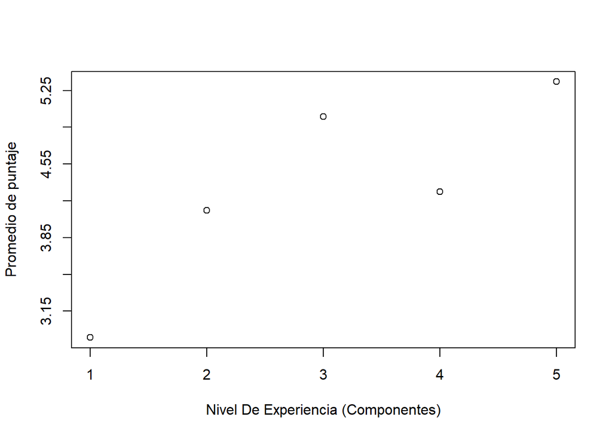

```r
score_mean <- score_mean[complete.cases(score_mean)]
score_mean <- c(0,0,0,0,0)
number_to_divide <- c(0,0,0,0,0)

for (row in 1:nrow(game_learning_cortado))
{
  score_mean[game_learning_cortado[row, "¿Cuál es tu nivel de conocimiento (previo a la experiencia) sobre componentes de computadora?"]] <- score_mean[game_learning_cortado[row, "¿Cuál es tu nivel de conocimiento (previo a la experiencia) sobre componentes de computadora?"]] + game_learning_cortado[row, "score_vector"]
  number_to_divide[game_learning_cortado[row, "¿Cuál es tu nivel de conocimiento (previo a la experiencia) sobre componentes de computadora?"]] <- number_to_divide[game_learning_cortado[row, "¿Cuál es tu nivel de conocimiento (previo a la experiencia) sobre componentes de computadora?"]] + 1
}

for (iterator in 1:5)
{
  score_mean[iterator] = score_mean[iterator]/number_to_divide[iterator]
}

possible <- c(1,2,3,4,5)

plot(possible,score_mean, xlab = "Nivel De Experiencia (Componentes)", ylab = "Promedio de puntaje", yaxp=c(0,7,20))
```

Tambien podemos ver el tiempo vs nota

```r
seconds <- as.numeric(as.period(ms(DF_scored$`Duración de la experiencia`), unit = "sec"))
DF_scored <- cbind(DF_scored, seconds)
```

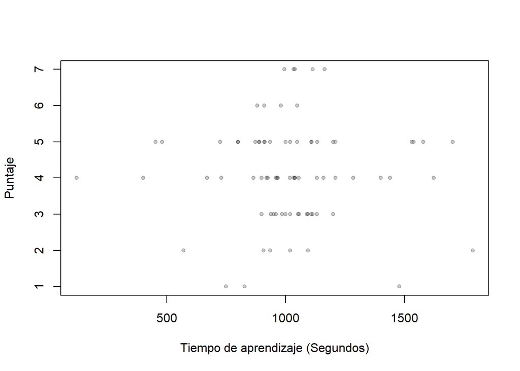

```r
plot(DF_scored$seconds, DF_scored$score_vector, pch = 20, col = rgb(0, 0, 0, 0.2), xlab="Tiempo de aprendizaje (Segundos)", ylab="Puntaje")
```

No parece haber una influencia del tiempo

```r
unique(DF$`Qué experiencia realizaste:`)
```

```
## [1] "Leer Documento PDF" "Jugar PC Simulator"
```

INICIO GANT

```r
library(tidyverse)
library(lubridate)
gantt <- read.csv("gant.csv", h=T)
```

```r
gantt$Inicio <- gsub("\\.", "-", gantt$Inicio)
gantt$Fin <- gsub("\\.", "-", gantt$Fin)
gantt$Inicio <- ymd(gantt$Inicio)
gantt$Fin <- ymd(gantt$Fin)
gantt.melt <- gantt%>%
  tidyr::pivot_longer(col = c(Inicio,Fin))
gantt.melt
```

| Item | Actividad | Elemento.del.Proyecto | Color | X | name | value |
| --- | --- | --- | --- | --- | --- | --- |
| 1 | Primer contacto con equipo de trabajo | Entregable P0 | red | NA | Inicio | 2022-03-21 |
| 1 | Primer contacto con equipo de trabajo | Entregable P0 | red | NA | Fin | 2022-03-29 |
| 2 | Reunion para definir temas de posible estudio estadistico | Entregable P0 | red | NA | Inicio | 2022-04-03 |
| 2 | Reunion para definir temas de posible estudio estadistico | Entregable P0 | red | NA | Fin | 2022-04-06 |
| 3 | Redaccion de informe para el entregable P0 | Entregable P0 | red | NA | Inicio | 2022-04-06 |
| 3 | Redaccion de informe para el entregable P0 | Entregable P0 | red | NA | Fin | 2022-04-08 |
| 4 | Espera de Feeback de entregable P0 | Entregable P0 | red | NA | Inicio | 2022-04-09 |
| 4 | Espera de Feeback de entregable P0 | Entregable P0 | red | NA | Fin | 2022-04-21 |
| 5 | Reunion para coordinar el tema final para el estudio estadistico | Tema de Investigacion | blue | NA | Inicio | 2022-04-28 |
| 5 | Reunion para coordinar el tema final para el estudio estadistico | Tema de Investigacion | blue | NA | Fin | 2022-04-30 |

[output cut: 18 more lines]

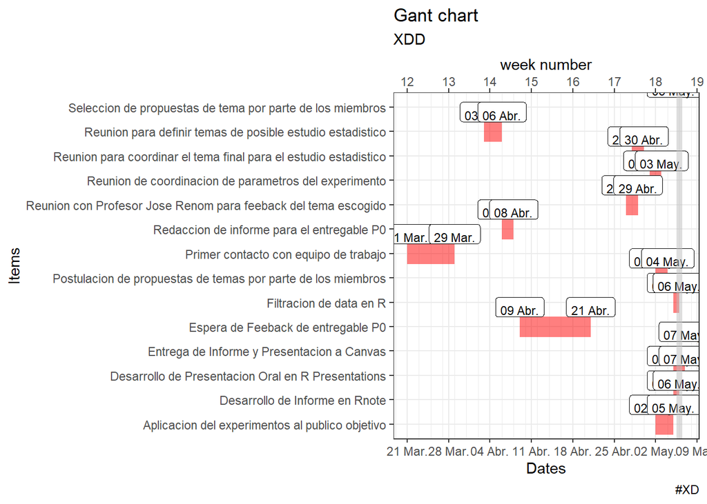

```r
today <- as.Date('2022-05-06')
#Sys.Date()

p1 <- ggplot(gantt.melt,aes(x = value,y = Actividad,colour = "red"))
p1 <- p1 + geom_line(alpha= 0.5, size = 7)
p1 <- p1 + geom_label(aes(label=format(value,"%d %b")),vjust = -0.5, angle = 45, size = 3, color = "black")
p1 <- p1 + theme_bw()
p1 <- p1 + geom_vline(xintercept = today,color = "grey", size = 2, alpha = 0.5 )
p1 <- p1 + labs(title = "Gant chart")
p1 <- p1 + labs(subtitle = "XDD")
p1 <- p1 + labs(caption = "#XD")
p1 <- p1 + labs(x="Date")
p1 <- p1 +  labs (y = "Items")
p1 <- p1 +  scale_color_manual(values = c("red","blue"))
p1 <- p1 +  theme(legend.position = "none")
p1 <- p1 + scale_x_date(name = "Dates"
                        , date_labels = "%d %b"
                        , date_breaks = "1 week"
                        , minor_breaks = "2 day"
                        , sec.axis = dup_axis(name = "week number",labels =   scales::date_format("%W"))
                        )

p1
```

```r
gantt <- read.csv("gant.csv", h=T)
gantt
```

| Item | Actividad | Elemento.del.Proyecto | Inicio | Fin | Color | X |
| --- | --- | --- | --- | --- | --- | --- |
| 1 | Primer contacto con equipo de trabajo | Entregable P0 | 2022.03.21 | 2022.03.29 | red | NA |
| 2 | Reunion para definir temas de posible estudio estadistico | Entregable P0 | 2022.04.03 | 2022.04.06 | red | NA |
| 3 | Redaccion de informe para el entregable P0 | Entregable P0 | 2022.04.06 | 2022.04.08 | red | NA |
| 4 | Espera de Feeback de entregable P0 | Entregable P0 | 2022.04.09 | 2022.04.21 | red | NA |
| 5 | Reunion para coordinar el tema final para el estudio estadistico | Tema de Investigacion | 2022.04.28 | 2022.04.30 | blue | NA |
| 6 | Postulacion de propuestas de temas por parte de los miembros | Tema de Investigacion | 2022.05.02 | 2022.05.04 | blue | NA |
| 7 | Seleccion de propuestas de tema por parte de los miembros | Tema de Investigacion | 2022.05.05 | 2022.05.05 | blue | NA |
| 8 | Reunion con Profesor Jose Renom para feeback del tema escogido | Parametros del experimento | 2022.04.27 | 2022.04.29 | green | NA |
| 9 | Reunion de coordinacion de parametros del experimento | Parametros del experimento | 2022.05.01 | 2022.05.03 | green | NA |
| 10 | Aplicacion del experimentos al publico objetivo | Desarrollo del Experimento | 2022.05.02 | 2022.05.05 | yellow | NA |

[output cut: 4 more lines]

```r
acts <- c("Primer contacto con equipo de trabajo", "Reunion para definir temas de posible estudio estadistico","Redaccion de informe para el entregable P0", "Espera de Feeback de entregable P0", "Reunion para coordinar el tema final para el estudio estadistico", "Postulacion de propuestas de temas por parte de los miembros", "Seleccion de propuestas de tema por parte de los miembros", "Reunion con Profesor Jose Renom para feeback del tema escogido", "Reunion de coordinacion de parametros del experimento", "Aplicacion del experimentos al publico objetivo", "Filtracion de data en R", "Desarrollo de Informe en Rnote", "Desarrollo de Presentacion Oral en R Presentations", "Entrega de Informe y Presentacion a Canvas")
els <- c("Entregable P0", "Tema de Investigacion", "Parametros del experimento", "Desarrollo del Experimento", "Entregable P1")

length(acts)
```

```
## [1] 14
```

```r
g.gantt <- gather(gantt, "state", "date", 4:5) %>% mutate(date = as.Date(date, "%Y.%m.%d"), Actividad=factor(Actividad, acts[length(acts):1]), Elemento.del.Proyecto =factor(Elemento.del.Proyecto, els))
g.gantt
```

| Item | Actividad | Elemento.del.Proyecto | Color | X | state | date |
| --- | --- | --- | --- | --- | --- | --- |
| 1 | Primer contacto con equipo de trabajo | Entregable P0 | red | NA | Inicio | 2022-03-21 |
| 2 | Reunion para definir temas de posible estudio estadistico | Entregable P0 | red | NA | Inicio | 2022-04-03 |
| 3 | Redaccion de informe para el entregable P0 | Entregable P0 | red | NA | Inicio | 2022-04-06 |
| 4 | Espera de Feeback de entregable P0 | Entregable P0 | red | NA | Inicio | 2022-04-09 |
| 5 | Reunion para coordinar el tema final para el estudio estadistico | Tema de Investigacion | blue | NA | Inicio | 2022-04-28 |
| 6 | Postulacion de propuestas de temas por parte de los miembros | Tema de Investigacion | blue | NA | Inicio | 2022-05-02 |
| 7 | Seleccion de propuestas de tema por parte de los miembros | Tema de Investigacion | blue | NA | Inicio | 2022-05-05 |
| 8 | Reunion con Profesor Jose Renom para feeback del tema escogido | Parametros del experimento | green | NA | Inicio | 2022-04-27 |
| 9 | Reunion de coordinacion de parametros del experimento | Parametros del experimento | green | NA | Inicio | 2022-05-01 |
| 10 | Aplicacion del experimentos al publico objetivo | Desarrollo del Experimento | yellow | NA | Inicio | 2022-05-02 |

[output cut: 18 more lines]

```r
#demosurv <- data.frame(state=rep(c("Inicio","Fin"), each=52), date=c(seq.Date(as.Date("2022.03.21"), as.Date("2022.05.06"), "3 week"), seq.Date(as.Date("2022.03.21"), as.Date("2022.05.06"), "3 week")), Actividad=rep(c(8.55,9.45), each=52),'Elemento del Proyecto'="", Item=rep(42:93, 2))
#head(g.gantt$Actividad)
```

[figure not shown]

```r
actcols <- c("#548235", "#2E75B6", "#BF9000", "#7030A0", "#cd6600")
ggplot(g.gantt, aes(date, Actividad, colour = Elemento.del.Proyecto, group=Item)) +
  geom_line(size = 10) +
  scale_color_manual(values=actcols, name="Project component") +
  labs(x="Semana Ciclo 2022-1", y=NULL, title="Project timeline") +
  scale_x_date(breaks=seq.Date(as.Date("2022-03-21"), as.Date("2022-5-06"), "weeks"), labels=c(1,2,3,4,5,6,7)) +
  theme_gray(base_size=14)
```

```r
DF <- read_csv("data.csv")
```

Filtrando todos los NA

```r
DF <- DF[complete.cases(DF),]
```

Medir puntaje

```r
score_vector = c()

for (ans in DF$`Regula y proporciona la potencia para que se activen todos los componentes de la PC:`)
{
  if (!is.na(ans))
  {
    if (ans == "Fuente de alimentación (PSU) o sistema de alimentación")
    {
      score_vector <- append(score_vector, 1)
    }
    else
    {
      score_vector <- append(score_vector, 0)
    }
  }
  else
  {
    score_vector <- append(score_vector, 0)
  }

}

iterator = 1
for (ans in DF$`Cuenta con sus propios procesadores y memoria interna que procesa los datos de la PC y los representa en forma de texto o gráficas complejas como la de los videojuegos. Nos referimos a:`)
{
  if (!is.na(ans))
  {
    if (ans == "Tarjeta gráfica (GPU)")
    {
      score_vector[iterator] = score_vector[iterator] + 1
    }
  }

  iterator = iterator + 1
}


iterator = 1
for (ans in DF$`Responsable realiza cálculos basados en la interpretación de la información de ciertos componentes y les pasa el resultado a otros. Nos referimos a:`)
{
  if (!is.na(ans))
  {
    if (ans == "Unidad central de procesamiento o Procesador (CPU)")
    {
      score_vector[iterator] <- score_vector[iterator] + 1
    }
  }

  iterator = iterator + 1
}


iterator = 1
for (ans in DF$`Almacena todos los datos del sistema operativo, los programas y las fotos, la música y los vídeos del usuario. Es decir, es el dispositivo de almacenamiento del ordenador.`)
{
  if (!is.na(ans))
  {
    if (ans == "Disco Duro")
    {
      score_vector[iterator] <- score_vector[iterator] + 1
    }
  }

  iterator = iterator + 1
}

iterator = 1
for (ans in DF$`¿Dónde se conecta o instala la memoria (RAM)?`)
{
  if (!is.na(ans))
  {
    if (ans == "Placa base (Motherboard)")
    {
      score_vector[iterator] <- score_vector[iterator] + 1
    }
  }

  iterator = iterator + 1
}

iterator = 1
for (ans in DF$`¿Dónde se coloca la pasta térmica?`)
{
  if (!is.na(ans))
  {
    if (ans == "Unidad central de procesamiento o Procesador (CPU)")
    {
      score_vector[iterator] <- score_vector[iterator] + 1
    }
  }

  iterator = iterator + 1
}

iterator = 1
for (ans in DF$`¿A que parte se conecta el panel frontal de la caja (botón de encendido/apagado, USB, conector de audio, etc)?`)
{
  if (!is.na(ans))
  {
    if (ans == "Placa base (Motherboard)")
    {
      score_vector[iterator] <- score_vector[iterator] + 1
    }
  }

  iterator = iterator + 1
}



DF_scored <- cbind(DF, score_vector)
```

Ahora veamos la data.

```r
class_learning <- DF_scored[DF_scored$`Qué experiencia realizaste:` == 'Leer Documento PDF',]



game_learning <- DF_scored[DF_scored$`Qué experiencia realizaste:` == 'Jugar PC Simulator',]

game_learning_cortado <- head(game_learning, nrow(class_learning) - nrow(game_learning))

nrow(game_learning_cortado)
```

```
## [1] 24
```

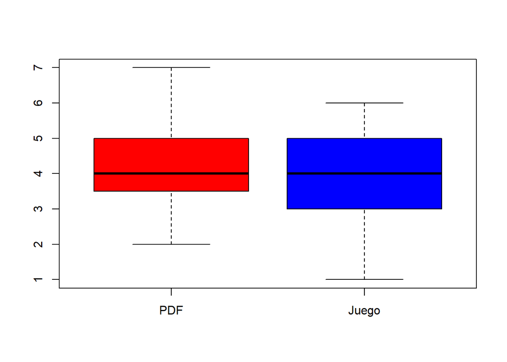

```r
data <- data.frame(class_learning$score_vector, game_learning_cortado$score_vector)
boxplot(data,names = c("PDF", "Juego"), col=c("Red", "Blue"))
```

Como podemos ver ahora hay una ligera inclinación a aquellos que tuvieron la experiencia tradicional de leer el pdf en la clase. Esto se puede deber a un sin fin de cosas, desde que aquellos seleccionados para jugar el “PC Building Simulator” y llenaron el form eran personas con menos tiempo hasta que decidieron llenarlo simplemente de forma no honesta. Cabe decir de que la selección de grupos no fue de forma aleatoria si no por conveniencia del entrevistador.

Por ultimo veamos las opiniones de los encuestados sobre su metodo favorito

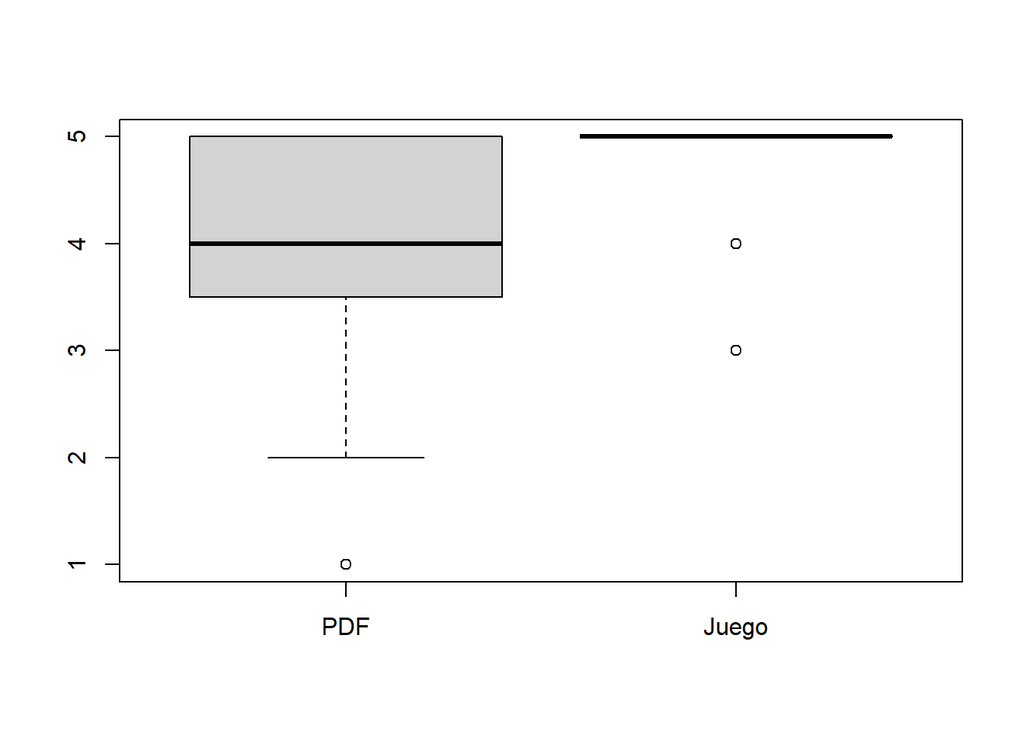

```r
class_learning <- DF_scored[DF_scored$`Qué experiencia realizaste:` == 'Leer Documento PDF',]



game_learning <- DF_scored[DF_scored$`Qué experiencia realizaste:` == 'Jugar PC Simulator',]

game_learning_cortado <- head(game_learning, nrow(class_learning) - nrow(game_learning))


data <- data.frame(class_learning$`Nivel de satisfacción al realizar el juego o leer el documento pdf:`, game_learning_cortado$`Nivel de satisfacción al realizar el juego o leer el documento pdf:`)
boxplot(data,names = c("PDF", "Juego"))
```

```r
mean(class_learning$`Nivel de satisfacción al realizar el juego o leer el documento pdf:`)
```

```
## [1] 4.041667
```

```r
mean(game_learning_cortado$`Nivel de satisfacción al realizar el juego o leer el documento pdf:`)
```

```
## [1] 4.708333
```

En conclusión por la escala del proyecto no podemos realmente asegurar alguna fuerte inclinación ni para la gamificación ni para la educación tradicional. Aunque nuestro estudio sugiere de que la educación tradicional parece ser mejor la diferencia es mínima y no es convulsiva. Tambien el estudio sugiere de que hay una buena preferencia por la Gamificación por parte de los estudiantes. Se necesitan mas estudios de una mayor amplitud para tener una conclusión definitiva.

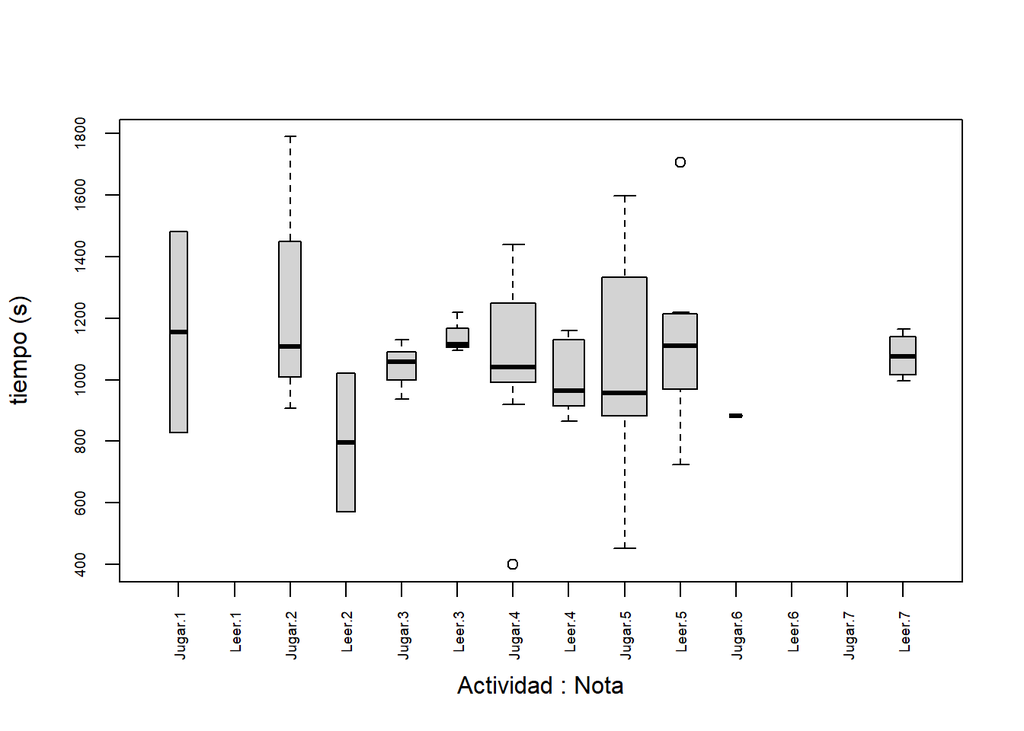

```r
DF_scored$`Qué experiencia realizaste:` <- ifelse(DF_scored$`Qué experiencia realizaste:` == "Leer Documento PDF", "Leer", "Jugar")

.MinaSeg <- function(x){
strs <- strsplit(x, ":")[[1]]
s <- sum(as.numeric(strs)*c(60, 1))
return(s)
}

MinaSeg <- Vectorize(.MinaSeg)

boxplot(MinaSeg(DF_scored$`Duración de la experiencia`) ~ DF_scored$`Qué experiencia realizaste:`:DF_scored$score_vector, varwidth = TRUE, las = 3, cex.axis = 0.6, xlab = "Actividad : Nota", ylab = "tiempo (s)")
```

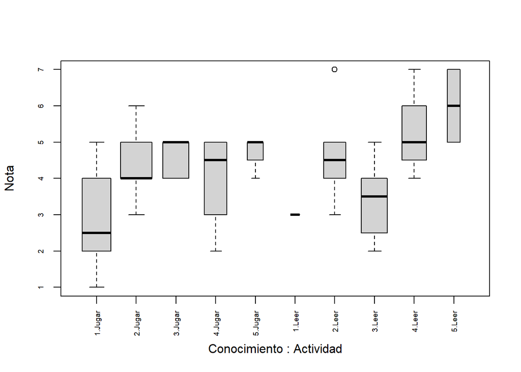

```r
boxplot(DF_scored$score_vector ~ DF_scored$`¿Cuál es tu nivel de conocimiento (previo a la experiencia) sobre componentes de computadora?`:DF_scored$`Qué experiencia realizaste:`, las = 3, cex.axis = 0.6, ylab = "Nota", xlab = "Conocimiento : Actividad", varwidth = TRUE)
```

```r
passed <- c(DF_scored$score_vector > 4)
avg <- sum(passed == TRUE)/length(passed)
avg
```

```
## [1] 0.4126984
```

Ahora podemos ver un grafico del modelo binomial del numero de estudiantes que se espera que pasaron el curso

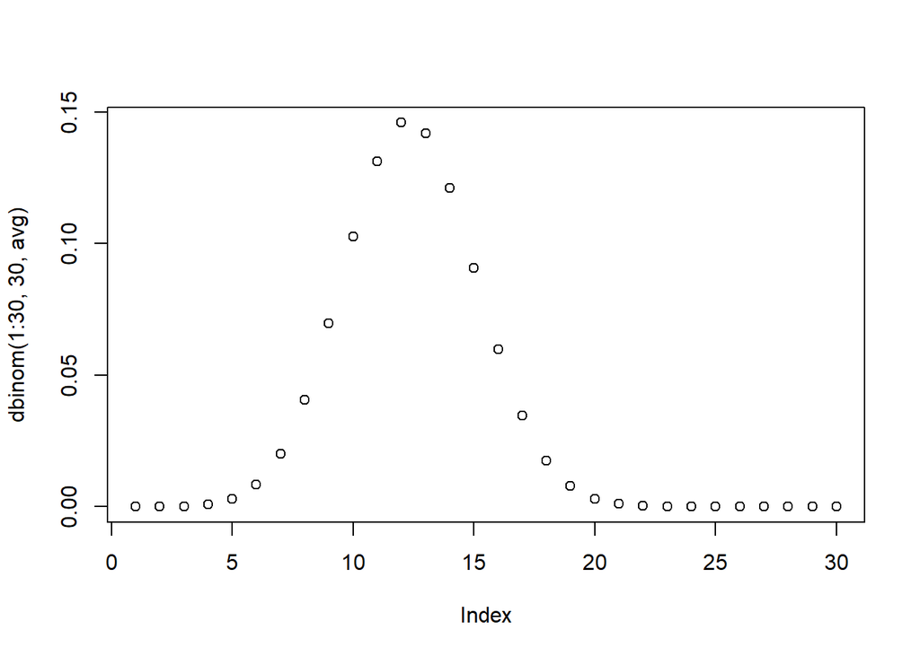

```r
plot(dbinom(1:30,30,avg))
```

Con una esperanza de:

```r
Esperanza <- length(passed)*avg
Esperanza
```

```
## [1] 26
```